# IODS course project

## Standardizing the dataset

Standardizing the data changed the range of the column values which are now much smaller. The column means are 0. Next we create a categorical variable of the crime rate using quantiles as breaking points and replace the old crime variable with the new categorical variable. Then the data set is divided creating a test and training data set.

```r
boston_scaled <- scale(Boston)
summary(boston_scaled)
```

```
##       crim                 zn               indus              chas
##  Min.   :-0.419367   Min.   :-0.48724   Min.   :-1.5563   Min.   :-0.2723
##  1st Qu.:-0.410563   1st Qu.:-0.48724   1st Qu.:-0.8668   1st Qu.:-0.2723
##  Median :-0.390280   Median :-0.48724   Median :-0.2109   Median :-0.2723
##  Mean   : 0.000000   Mean   : 0.00000   Mean   : 0.0000   Mean   : 0.0000
##  3rd Qu.: 0.007389   3rd Qu.: 0.04872   3rd Qu.: 1.0150   3rd Qu.:-0.2723
##  Max.   : 9.924110   Max.   : 3.80047   Max.   : 2.4202   Max.   : 3.6648
##       nox                rm               age               dis
##  Min.   :-1.4644   Min.   :-3.8764   Min.   :-2.3331   Min.   :-1.2658
##  1st Qu.:-0.9121   1st Qu.:-0.5681   1st Qu.:-0.8366   1st Qu.:-0.8049
##  Median :-0.1441   Median :-0.1084   Median : 0.3171   Median :-0.2790
##  Mean   : 0.0000   Mean   : 0.0000   Mean   : 0.0000   Mean   : 0.0000
##  3rd Qu.: 0.5981   3rd Qu.: 0.4823   3rd Qu.: 0.9059   3rd Qu.: 0.6617
##  Max.   : 2.7296   Max.   : 3.5515   Max.   : 1.1164   Max.   : 3.9566
##       rad               tax             ptratio            black
##  Min.   :-0.9819   Min.   :-1.3127   Min.   :-2.7047   Min.   :-3.9033
##  1st Qu.:-0.6373   1st Qu.:-0.7668   1st Qu.:-0.4876   1st Qu.: 0.2049
##  Median :-0.5225   Median :-0.4642   Median : 0.2746   Median : 0.3808
##  Mean   : 0.0000   Mean   : 0.0000   Mean   : 0.0000   Mean   : 0.0000
##  3rd Qu.: 1.6596   3rd Qu.: 1.5294   3rd Qu.: 0.8058   3rd Qu.: 0.4332
##  Max.   : 1.6596   Max.   : 1.7964   Max.   : 1.6372   Max.   : 0.4406
##      lstat              medv
##  Min.   :-1.5296   Min.   :-1.9063
##  1st Qu.:-0.7986   1st Qu.:-0.5989
##  Median :-0.1811   Median :-0.1449
##  Mean   : 0.0000   Mean   : 0.0000
##  3rd Qu.: 0.6024   3rd Qu.: 0.2683
##  Max.   : 3.5453   Max.   : 2.9865
```

```r
# Save as data frame
boston_scaled<-as.data.frame(boston_scaled)

summary(boston_scaled$crim)
```

```
##      Min.   1st Qu.    Median      Mean   3rd Qu.      Max.
## -0.419367 -0.410563 -0.390280  0.000000  0.007389  9.924110
```

```r
#Setting quantiles as breaks for categoricals crime variable
bins <- quantile(boston_scaled$crim)
crime <- cut(boston_scaled$crim, breaks = bins, include.lowest = TRUE)
boston_scaled <- dplyr::select(boston_scaled, -crim)
boston_scaled <- data.frame(boston_scaled, crime)

#Creating traning set
library(dplyr)
library(MASS)
boston_scaled <- read.table("https://raw.githubusercontent.com/KimmoVehkalahti/Helsinki-Open-Data-Science/master/datasets/boston_scaled.txt",
                            sep=",", header = T)
boston_scaled$crime <- factor(boston_scaled$crime, levels = c("low", "med_low", "med_high", "high"))

n <- nrow(boston_scaled)
ind <- sample(n,  size = n * 0.8)
train <- boston_scaled[ind,]
test <- boston_scaled[-ind,]
correct_classes <- test$crime
test <- dplyr::select(test, -crime)

#Fitting the linead discriminate model

lda.fit <- lda(crime~., data = train)

# print the lda.fit object
lda.fit
```

```
## Call:
## lda(crime ~ ., data = train)
##
## Prior probabilities of groups:
##       low   med_low  med_high      high
## 0.2574257 0.2450495 0.2524752 0.2450495
##
## Group means:
##                  zn      indus         chas        nox         rm        age
## low       0.9547097 -0.9057969 -0.120902136 -0.8721470  0.4180390 -0.8636398
## med_low  -0.1178038 -0.2672082  0.006051757 -0.5284143 -0.1384981 -0.2787544
## med_high -0.3762641  0.1309865  0.190859195  0.3133886  0.1541337  0.3821978
## high     -0.4872402  1.0171737 -0.033716932  1.0902466 -0.4168514  0.8367078
##                 dis        rad        tax     ptratio      black       lstat
## low       0.9338374 -0.6881287 -0.7506714 -0.44669579  0.3796617 -0.73678523
## med_low   0.3175650 -0.5422055 -0.4720045 -0.07370809  0.3178502 -0.09752004
## med_high -0.3226039 -0.3828668 -0.3165760 -0.26566093  0.1531515 -0.05831018
## high     -0.8679709  1.6375616  1.5136504  0.78011702 -0.9051046  0.94357805
##                  medv
## low       0.509972547
## med_low   0.003022662
## med_high  0.225085509
## high     -0.698120305
##
## Coefficients of linear discriminants:
##                  LD1         LD2         LD3
## zn       0.085287265  0.80858062 -0.81419917
## indus    0.001489293 -0.24640826  0.20070637
## chas    -0.070480597 -0.06820961  0.10367350
## nox      0.455497538 -0.57340966 -1.57224764
## rm      -0.060418646 -0.09260976 -0.13925586
## age      0.265293931 -0.35857148 -0.16698394
## dis     -0.023729639 -0.21213846 -0.06862736
## rad      2.943626714  0.86980533 -0.11835850
## tax      0.002922534 -0.05227162  0.68738495
## ptratio  0.113424343  0.09956660 -0.27962513
## black   -0.144828086 -0.04807898  0.08839699
## lstat    0.234782589 -0.09177792  0.46510443
## medv     0.197706554 -0.26998622 -0.22739771
##
## Proportion of trace:
##    LD1    LD2    LD3
## 0.9473 0.0392 0.0135
```

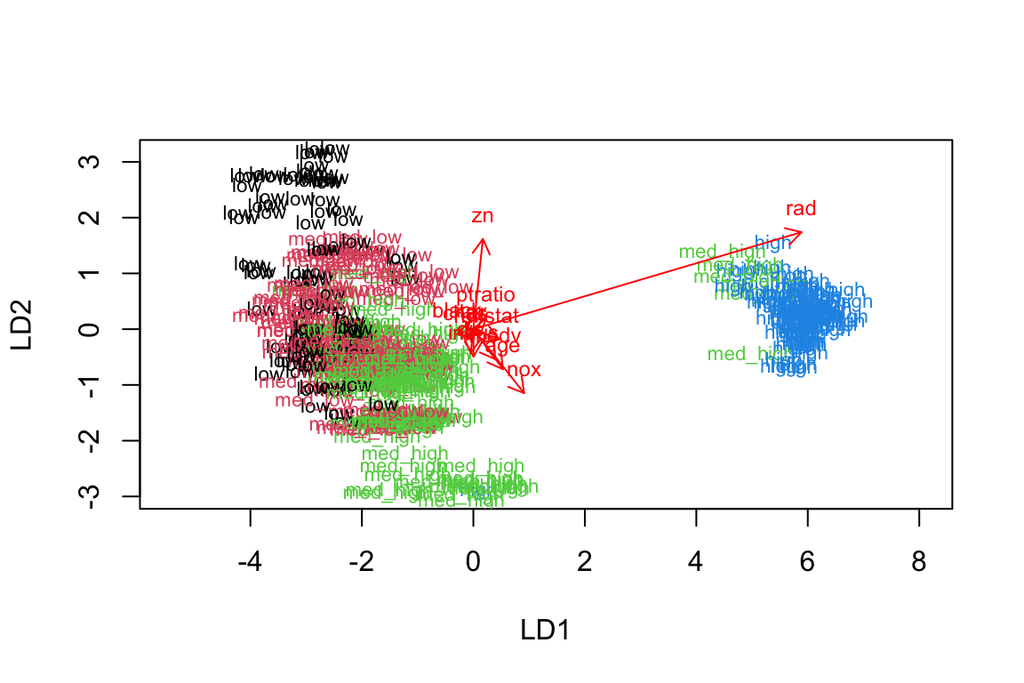

```r
# the function for lda biplot arrows
lda.arrows <- function(x, myscale = 2, arrow_heads = 0.1, color = "red", tex = 0.75, choices = c(1,2)){
  heads <- coef(x)
  arrows(x0 = 0, y0 = 0,
         x1 = myscale * heads[,choices[1]],
         y1 = myscale * heads[,choices[2]], col=color, length = arrow_heads)
  text(myscale * heads[,choices], labels = row.names(heads),
       cex = tex, col=color, pos=3)
}

# target classes as numeric

classes <- as.numeric(factor(train$crime))

# plot the lda results
plot(lda.fit, dimen = 2,col = classes, pch = classes)
lda.arrows(lda.fit, myscale = 2)
```

## Linear discriminate analysis

The linear discriminate plot above shows the clusters of towns with high crime rate on the right side of the graph and other categories of crime rates (low, med low, med high) on the left. Arrows representing the effect size of each explanatory variable are drawn on the graph with rad having the longest arrow towards high crime rate. This means that for any given suburb easier access to the radial highways of greater Boston is associated with criminality.

```r
#Reloading the Boston data and standardizing it
library(MASS)
data("Boston")
boston_scaled2<-as.data.frame(scale(Boston))

#Calculate distances
dist_eu <- dist(boston_scaled2)
summary(dist_eu)
```

```
##    Min. 1st Qu.  Median    Mean 3rd Qu.    Max.
##  0.1343  3.4625  4.8241  4.9111  6.1863 14.3970
```

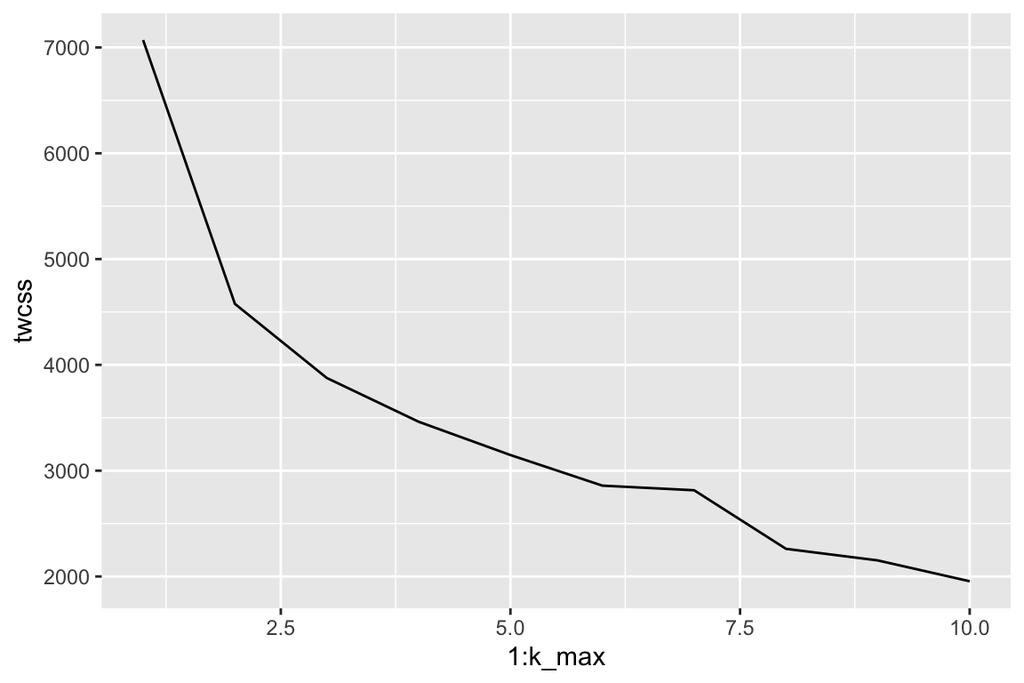

```r
#Calculating WCSS to determine optimal number of clusters
set.seed(123)
k_max <- 10
twcss <- sapply(1:k_max, function(k){kmeans(boston_scaled2, k)$tot.withinss})
qplot(x = 1:k_max, y = twcss, geom = 'line')
```

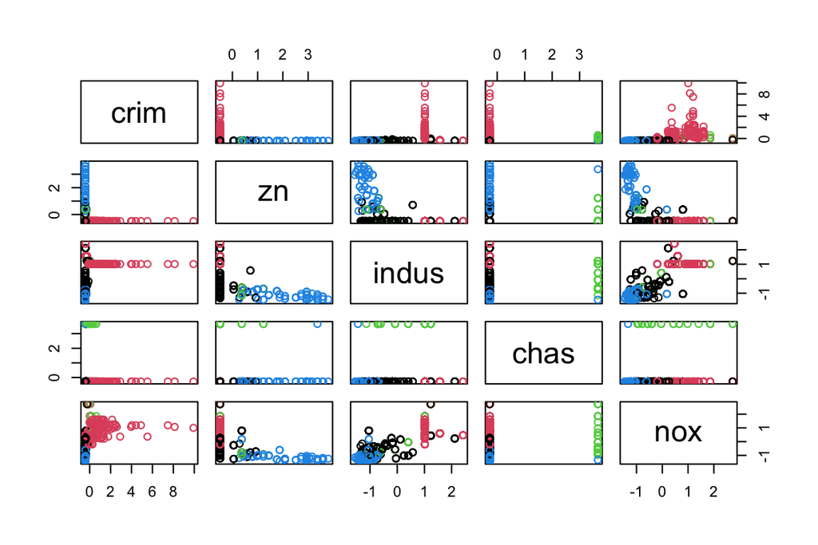

```r
#K-means

km <- kmeans(boston_scaled2, centers = 4)
pairs(boston_scaled2[, 1:5], col = km$cluster)
```

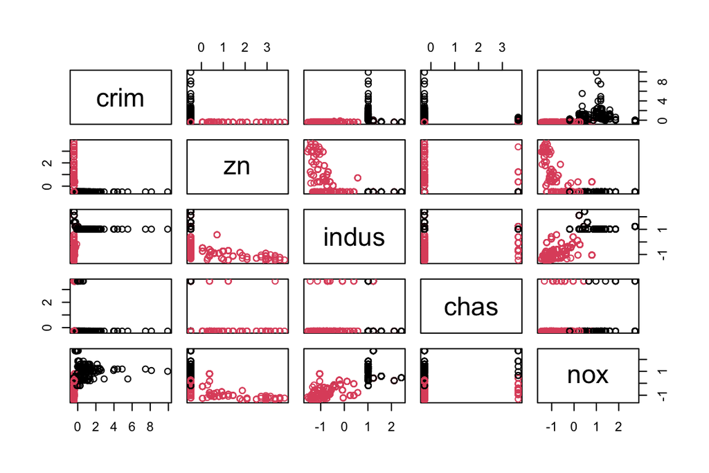

```r
#Repeating with two clusters
km <- kmeans(boston_scaled2, centers = 2)
pairs(boston_scaled2[, 1:5], col = km$cluster)
```

## K-means clustering

Based on the calculations for within cluster sum of squares (WCSS) the optimal number of clusters is two. This is the point at which the value of total WCSS changes radically and the curve tilts the most. For the sake of comparison the k-means clustering is drawn with both four and two clusters. For sake of readability only the first five variables were included for this graphical data clustering.

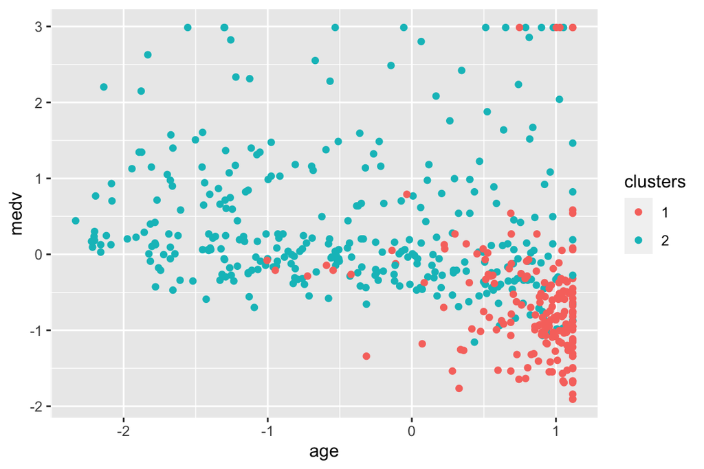

```r
# Drawing a scatter plot to see if older houses are less valuable than new ones
library(tidyverse)
clusters <- factor(km$cluster)
boston_scaled2 %>% ggplot(aes(x = age, y = medv, col = clusters)) +
  geom_point()
```

The scatter plot shows an example of clustering the observations based on the proportion of owner-occupied units built prior to 1940 (age) and median value of owner-occupied homes in usd 1000s (medv). The red cluster 1 in the lower right corner denotes the cheaper and older housing properties. The second green cluster is more evenlöy distributed.

### *Thank you for reading my report for the week assignment. Have an awesome day!*